# League of Legends Final Tutorial

### Created by Corey Huang, Nishar Pillai, and Julien Heurteux

## Introduction

League of Legends is a Multiplayer Online Battle Arena (MOBA) game created by Riot Games in 2009. The game boasts an average of 700,000 concurrent players daily and 112 million monthly players 12 years after release. League is a deceptively simple game with one objective: destroy the enemy team's "nexus tower". Each team competes head to head on an even stage in order to achieve that objective. In each game, there are optional objectives that teams can fight over in order to gain bonus stats to aide in capturing the final objective. With over 150 unique champions each with their own playstyle, there is something enjoyable for everyone.

Our motivation for analyzing factors behind win rate in League stems from how we are all active players of the game looking to have a deeper understanding of what affects a victory or loss. With the assistance of Riot's Data Dragon, game data from Korea can be extracted in order to analyze some of the quantitative factors of League games. An example of this is number of dragons, rift heralds, and barons collected by each team. This data shows games from the highest ranked players in the Korean Server over the full year of 2020.

In our tutorial, our goal is to read and tidy the data provided by Riot's API, process the data to determine which bonus objectives are most important in terms of contributing to a team's victory and be able to predict whether a not or team is likely to win given what bonus objectives they have accomplished at a certain point in the game. The aforementioned bonus objectives provide different benefits, such as giving a player the ability to summon a monster to help destroy turrets, giving every player on a team permanent buffs to various stats such as attack or health regeneration, or giving every player on a team a temporary ability to buff nearby minions. The difficulty of and appearance of these bonus objectives vary over time, so with our analysis we hope to help provide evidence for both new and old players on which bonus objectives are worth focusing on and to hopefully help players improve by allowing them to make better decisions regarding the various tradeoffs they can make.

## Preprocessing Data

To read our data, we will be using the pickle library. For our analysis, we will be using multiple libraries such as numpy, pandas, and matplot.

```python
import numpy as np
import pandas as pd
import pickle
import matplotlib.pyplot as plt
import numpy as np
import seaborn
import sklearn
from sklearn.model_selection import train_test_split
from sklearn.ensemble import RandomForestClassifier
from sklearn.tree import DecisionTreeClassifier
from sklearn.model_selection import cross_val_score
from sklearn import metrics
```

The data can be downloaded at https://www.kaggle.com/datasets/gyejr95/league-of-legendslol-ranked-games-2020-ver1.

The original dataset that we download from Kaggle is over a gigabyte in size, so cutting it down was necessary. Fortunately, the creator of the dataset has created includes separate CSV files for both teams of winners and teams of losers, as well as the original dataset labeled match_data_version1.

```python
winner_df =  pd.read_pickle('match_winner_data_version1.pickle')
loser_df = pd.read_pickle('match_loser_data_version1.pickle')
match_df = pd.read_pickle('match_data_version1.pickle')
display(match_df)
```

|  | gameCreation | gameDuration | gameId | gameMode | gameType | gameVersion | mapId | participantIdentities | participants | platformId | queueId | seasonId | status.message | status.status_code |
| --- | --- | --- | --- | --- | --- | --- | --- | --- | --- | --- | --- | --- | --- | --- |
| 0 | 1.585155e+12 | 1323.0 | 4.247263e+09 | CLASSIC | MATCHED_GAME | 10.6.314.4405 | 11.0 | [{'participantId': 1, 'player': {'platformId':... | [{'participantId': 1, 'teamId': 100, 'champion... | KR | 420.0 | 13.0 | NaN | NaN |
| 1 | 1.585152e+12 | 1317.0 | 4.247156e+09 | CLASSIC | MATCHED_GAME | 10.6.314.4405 | 11.0 | [{'participantId': 1, 'player': {'platformId':... | [{'participantId': 1, 'teamId': 100, 'champion... | KR | 420.0 | 13.0 | NaN | NaN |
| 2 | 1.585059e+12 | 932.0 | 4.243963e+09 | CLASSIC | MATCHED_GAME | 10.6.313.8894 | 11.0 | [{'participantId': 1, 'player': {'platformId':... | [{'participantId': 1, 'teamId': 100, 'champion... | KR | 420.0 | 13.0 | NaN | NaN |
| 3 | 1.584978e+12 | 2098.0 | 4.241678e+09 | CLASSIC | MATCHED_GAME | 10.6.313.8894 | 11.0 | [{'participantId': 1, 'player': {'platformId':... | [{'participantId': 1, 'teamId': 100, 'champion... | KR | 420.0 | 13.0 | NaN | NaN |
| 4 | 1.584973e+12 | 2344.0 | 4.241539e+09 | CLASSIC | MATCHED_GAME | 10.6.313.8894 | 11.0 | [{'participantId': 1, 'player': {'platformId':... | [{'participantId': 1, 'teamId': 100, 'champion... | KR | 420.0 | 13.0 | NaN | NaN |
| ... | ... | ... | ... | ... | ... | ... | ... | ... | ... | ... | ... | ... | ... | ... |
| 0 | 1.579163e+12 | 1029.0 | 4.088497e+09 | URF | MATCHED_GAME | 10.1.303.9385 | 11.0 | [{'participantId': 1, 'player': {'platformId':... | [{'participantId': 1, 'teamId': 100, 'champion... | KR | 900.0 | 13.0 | NaN | NaN |
| 0 | 1.580823e+12 | 1544.0 | 4.130964e+09 | CLASSIC | MATCHED_GAME | 10.2.305.4739 | 11.0 | [{'participantId': 1, 'player': {'platformId':... | [{'participantId': 1, 'teamId': 100, 'champion... | KR | 420.0 | 13.0 | NaN | NaN |
| 0 | 1.580382e+12 | 2090.0 | 4.119954e+09 | CLASSIC | MATCHED_GAME | 10.2.305.4739 | 11.0 | [{'participantId': 1, 'player': {'platformId':... | [{'participantId': 1, 'teamId': 100, 'champion... | KR | 420.0 | 13.0 | NaN | NaN |
| 0 | 1.580805e+12 | 1382.0 | 4.130440e+09 | URF | MATCHED_GAME | 10.2.305.4739 | 11.0 | [{'participantId': 1, 'player': {'platformId':... | [{'participantId': 1, 'teamId': 100, 'champion... | KR | 900.0 | 13.0 | NaN | NaN |
| 0 | 1.584505e+12 | 1432.0 | 4.225861e+09 | ARAM | MATCHED_GAME | 10.6.313.2784 | 12.0 | [{'participantId': 1, 'player': {'platformId':... | [{'participantId': 1, 'teamId': 100, 'champion... | KR | 450.0 | 13.0 | NaN | NaN |

108829 rows × 14 columns

- GameCreation: A unique number tied to the creation of the game
- GameDuration: How many seconds a game lasted
- GameId: A unique number tied to the game and its participants
- GameMode: The gamemode (Classic, ARAM, URF, etc.)
- GameType: The type of game (Custom or Normal)
- GameVersion: What version of the game was played
- MapId: What map the game was played on
- ParticipantIds: Participant names and profiles
- Participants: How each participant performed in the game
- PlatformId: What country the game is played in
- QueueId: What type of queue the players used (Ranked Solo, Normal, One for All, etc.)
- SeasonId: What season the game is played in
- Status.message and Status.status_code which are both null

```python
winner_df.head()
```

|  | teamId | win | firstBlood | firstTower | firstInhibitor | firstBaron | firstDragon | firstRiftHerald | towerKills | inhibitorKills | baronKills | dragonKills | vilemawKills | riftHeraldKills | dominionVictoryScore | bans | gameId |
| --- | --- | --- | --- | --- | --- | --- | --- | --- | --- | --- | --- | --- | --- | --- | --- | --- | --- |
| 0 | 200 | Win | False | True | True | False | True | True | 9 | 1 | 0 | 3 | 0 | 2 | 0 | [{'championId': 523, 'pickTurn': 6}, {'champio... | 4.247263e+09 |
| 1 | 100 | Win | False | False | False | False | True | True | 4 | 0 | 0 | 2 | 0 | 2 | 0 | [{'championId': 523, 'pickTurn': 1}, {'champio... | 4.247156e+09 |
| 2 | 200 | Win | True | True | True | False | True | True | 5 | 1 | 0 | 2 | 0 | 2 | 0 | [{'championId': 350, 'pickTurn': 6}, {'champio... | 4.243963e+09 |
| 3 | 200 | Win | True | True | False | False | False | True | 6 | 0 | 1 | 3 | 0 | 1 | 0 | [{'championId': 81, 'pickTurn': 6}, {'champion... | 4.241678e+09 |
| 4 | 100 | Win | True | True | True | True | True | True | 11 | 3 | 2 | 2 | 0 | 2 | 0 | [{'championId': 30, 'pickTurn': 1}, {'champion... | 4.241539e+09 |

```python
loser_df.head()
```

|  | teamId | win | firstBlood | firstTower | firstInhibitor | firstBaron | firstDragon | firstRiftHerald | towerKills | inhibitorKills | baronKills | dragonKills | vilemawKills | riftHeraldKills | dominionVictoryScore | bans | gameId |
| --- | --- | --- | --- | --- | --- | --- | --- | --- | --- | --- | --- | --- | --- | --- | --- | --- | --- |
| 0 | 100 | Fail | True | False | False | False | False | False | 0 | 0 | 0 | 0 | 0 | 0 | 0 | [{'championId': -1, 'pickTurn': 1}, {'champion... | 4.247263e+09 |
| 1 | 200 | Fail | True | True | False | False | False | False | 2 | 0 | 0 | 0 | 0 | 0 | 0 | [{'championId': 875, 'pickTurn': 6}, {'champio... | 4.247156e+09 |
| 2 | 100 | Fail | False | False | False | False | False | False | 0 | 0 | 0 | 0 | 0 | 0 | 0 | [{'championId': 110, 'pickTurn': 1}, {'champio... | 4.243963e+09 |
| 3 | 100 | Fail | False | False | False | True | True | False | 2 | 0 | 1 | 1 | 0 | 0 | 0 | [{'championId': 523, 'pickTurn': 1}, {'champio... | 4.241678e+09 |
| 4 | 200 | Fail | False | False | False | False | False | False | 6 | 1 | 1 | 3 | 0 | 0 | 0 | [{'championId': 523, 'pickTurn': 6}, {'champio... | 4.241539e+09 |

Both the winner and loser dataframes above have the same column types that are derived from the participants section of the match_data_version1 data. The 17 columns in each are:

- teamId: If they were red or blue
- win: If they won the game
- firstBlood: If they got the first kill in the game
- firstTower: If they got the first tower in the game
- firstInhibitor: If they got the first inhibitor in the game
- firstBaron: If they got the first Baron in the game
- firstDragon: If they got the first Dragon in the game
- firstRiftHerald: If they got the first Rift Herald in the game
- towerKills: The amount of towers the team destroyed
- inhibitorKills: The amount of inhibitors the team destroyed
- baronKills: The amount of Barons the team killed
- dragonKills: The amount of Dragons the team killed
- vilemawKills: The amount of Vilemaws the team killed
- riftHeraldKills: The amount of Rift Heralds the team killed
- dominionVictoryScore: The teams Dominion score (when applicable)
- bans: List of champion ids that were banned
- gameId: A unique number that identifies the game

We can merge the datasets using the unique gameId:

```python
# Merge winner and loser datasets
merge1_df = winner_df.merge(match_df, left_on='gameId', right_on='gameId')
merge2_df = merge1_df.merge(loser_df, left_on='gameId', right_on='gameId')
display(merge2_df)
```

|  | teamId_x | win_x | firstBlood_x | firstTower_x | firstInhibitor_x | firstBaron_x | firstDragon_x | firstRiftHerald_x | towerKills_x | inhibitorKills_x | ... | firstDragon_y | firstRiftHerald_y | towerKills_y | inhibitorKills_y | baronKills_y | dragonKills_y | vilemawKills_y | riftHeraldKills_y | dominionVictoryScore_y | bans_y |
| --- | --- | --- | --- | --- | --- | --- | --- | --- | --- | --- | --- | --- | --- | --- | --- | --- | --- | --- | --- | --- | --- |
| 0 | 200 | Win | False | True | True | False | True | True | 9 | 1 | ... | False | False | 0 | 0 | 0 | 0 | 0 | 0 | 0 | [{'championId': -1, 'pickTurn': 1}, {'champion... |
| 1 | 100 | Win | False | False | False | False | True | True | 4 | 0 | ... | False | False | 2 | 0 | 0 | 0 | 0 | 0 | 0 | [{'championId': 875, 'pickTurn': 6}, {'champio... |
| 2 | 200 | Win | True | True | True | False | True | True | 5 | 1 | ... | False | False | 0 | 0 | 0 | 0 | 0 | 0 | 0 | [{'championId': 110, 'pickTurn': 1}, {'champio... |
| 3 | 200 | Win | True | True | False | False | False | True | 6 | 0 | ... | True | False | 2 | 0 | 1 | 1 | 0 | 0 | 0 | [{'championId': 523, 'pickTurn': 1}, {'champio... |
| 4 | 100 | Win | True | True | True | True | True | True | 11 | 3 | ... | False | False | 6 | 1 | 1 | 3 | 0 | 0 | 0 | [{'championId': 523, 'pickTurn': 6}, {'champio... |
| ... | ... | ... | ... | ... | ... | ... | ... | ... | ... | ... | ... | ... | ... | ... | ... | ... | ... | ... | ... | ... | ... |
| 109160 | 100 | Win | False | True | True | True | True | False | 9 | 2 | ... | False | False | 3 | 0 | 0 | 1 | 0 | 0 | 0 | [] |
| 109161 | 100 | Win | True | False | False | True | False | False | 5 | 0 | ... | True | True | 3 | 0 | 0 | 2 | 0 | 2 | 0 | [{'championId': 84, 'pickTurn': 6}, {'champion... |
| 109162 | 100 | Win | False | False | False | True | False | False | 6 | 1 | ... | True | True | 6 | 1 | 0 | 3 | 0 | 1 | 0 | [{'championId': 107, 'pickTurn': 6}, {'champio... |
| 109163 | 100 | Win | True | True | True | False | False | False | 10 | 2 | ... | True | False | 5 | 0 | 1 | 3 | 0 | 0 | 0 | [] |
| 109164 | 100 | Win | False | True | False | False | False | False | 4 | 2 | ... | False | False | 4 | 2 | 0 | 0 | 0 | 0 | 0 | [] |

109165 rows × 46 columns

## Tidying Data

For our analysis, we are interested in exploring the significance of the bonus objectives within the game and how important they are to obtaining victory. In addition, we want to specifically look at a single game mode type for consistency within our data. As a result, we will narrow our dataset to only look at classical ranked solo queue games on Summoner's Rift because it is the most common and popular game mode while also being competitive. To do this, we can look at Riot's API documentation to see that we can obtain the data we want by filtering for gameMode = CLASSIC and mapID = 11 for Summoner's Rift, and queueId = 420 for ranked solo queue. To keep the data even more consistent, we will also filter for the most recent version of the game using seasonId = 13 for season 2019.

https://static.developer.riotgames.com/docs/lol/gameModes.json

https://static.developer.riotgames.com/docs/lol/maps.json

https://static.developer.riotgames.com/docs/lol/queues.json

https://static.developer.riotgames.com/docs/lol/seasons.json

```python
# Filter dataset to only relevant games
merge2_df = merge2_df[(merge2_df.gameMode == "CLASSIC") & (merge2_df.mapId == 11) & (merge2_df.queueId == 420) & (merge2_df.seasonId == 13)]
display(merge2_df)
```

|  | teamId_x | win_x | firstBlood_x | firstTower_x | firstInhibitor_x | firstBaron_x | firstDragon_x | firstRiftHerald_x | towerKills_x | inhibitorKills_x | ... | firstDragon_y | firstRiftHerald_y | towerKills_y | inhibitorKills_y | baronKills_y | dragonKills_y | vilemawKills_y | riftHeraldKills_y | dominionVictoryScore_y | bans_y |
| --- | --- | --- | --- | --- | --- | --- | --- | --- | --- | --- | --- | --- | --- | --- | --- | --- | --- | --- | --- | --- | --- |
| 0 | 200 | Win | False | True | True | False | True | True | 9 | 1 | ... | False | False | 0 | 0 | 0 | 0 | 0 | 0 | 0 | [{'championId': -1, 'pickTurn': 1}, {'champion... |
| 1 | 100 | Win | False | False | False | False | True | True | 4 | 0 | ... | False | False | 2 | 0 | 0 | 0 | 0 | 0 | 0 | [{'championId': 875, 'pickTurn': 6}, {'champio... |
| 2 | 200 | Win | True | True | True | False | True | True | 5 | 1 | ... | False | False | 0 | 0 | 0 | 0 | 0 | 0 | 0 | [{'championId': 110, 'pickTurn': 1}, {'champio... |
| 3 | 200 | Win | True | True | False | False | False | True | 6 | 0 | ... | True | False | 2 | 0 | 1 | 1 | 0 | 0 | 0 | [{'championId': 523, 'pickTurn': 1}, {'champio... |
| 4 | 100 | Win | True | True | True | True | True | True | 11 | 3 | ... | False | False | 6 | 1 | 1 | 3 | 0 | 0 | 0 | [{'championId': 523, 'pickTurn': 6}, {'champio... |
| ... | ... | ... | ... | ... | ... | ... | ... | ... | ... | ... | ... | ... | ... | ... | ... | ... | ... | ... | ... | ... | ... |
| 109155 | 200 | Win | True | True | False | False | True | True | 2 | 0 | ... | False | False | 0 | 0 | 0 | 0 | 0 | 0 | 0 | [{'championId': 523, 'pickTurn': 1}, {'champio... |
| 109156 | 100 | Win | True | False | True | True | False | True | 11 | 3 | ... | True | False | 1 | 0 | 0 | 1 | 0 | 0 | 0 | [{'championId': 157, 'pickTurn': 6}, {'champio... |
| 109157 | 100 | Win | True | True | True | False | True | True | 5 | 1 | ... | False | False | 0 | 0 | 0 | 0 | 0 | 0 | 0 | [{'championId': 523, 'pickTurn': 6}, {'champio... |
| 109161 | 100 | Win | True | False | False | True | False | False | 5 | 0 | ... | True | True | 3 | 0 | 0 | 2 | 0 | 2 | 0 | [{'championId': 84, 'pickTurn': 6}, {'champion... |
| 109162 | 100 | Win | False | False | False | True | False | False | 6 | 1 | ... | True | True | 6 | 1 | 0 | 3 | 0 | 1 | 0 | [{'championId': 107, 'pickTurn': 6}, {'champio... |

78123 rows × 46 columns

Next we will drop every column except the ones related to nonessential objectives. This would include first Dragon, first Baron, first Rift Herald, Dragon kills, Baron kills, and Rift Herald kills.

```python
#Filter columns to just bonus objectives
final = merge2_df[['dragonKills_x', 'baronKills_x', 'riftHeraldKills_x', 'dragonKills_y', 'baronKills_y', 'riftHeraldKills_y','firstDragon_x', 'firstBaron_x', 'firstRiftHerald_x']]
display(final)
```

|  | dragonKills_x | baronKills_x | riftHeraldKills_x | dragonKills_y | baronKills_y | riftHeraldKills_y | firstDragon_x | firstBaron_x | firstRiftHerald_x |
| --- | --- | --- | --- | --- | --- | --- | --- | --- | --- |
| 0 | 3 | 0 | 2 | 0 | 0 | 0 | True | False | True |
| 1 | 2 | 0 | 2 | 0 | 0 | 0 | True | False | True |
| 2 | 2 | 0 | 2 | 0 | 0 | 0 | True | False | True |
| 3 | 3 | 1 | 1 | 1 | 1 | 0 | False | False | True |
| 4 | 2 | 2 | 2 | 3 | 1 | 0 | True | True | True |
| ... | ... | ... | ... | ... | ... | ... | ... | ... | ... |
| 109155 | 1 | 0 | 1 | 0 | 0 | 0 | True | False | True |
| 109156 | 2 | 1 | 2 | 1 | 0 | 0 | False | True | True |
| 109157 | 1 | 0 | 1 | 0 | 0 | 0 | True | False | True |
| 109161 | 2 | 1 | 0 | 2 | 0 | 2 | False | True | False |
| 109162 | 3 | 2 | 1 | 3 | 0 | 1 | False | True | False |

78123 rows × 9 columns

Finally we can rename the left and right column names to indicate whether they represent the winning or losing team.

```python
final.columns = ['dk_win', 'bk_win', 'rhk_win', 'dk_loss', 'bk_loss', 'rhk_loss', 'firstDk_win', 'firstBk_win', 'firstRHk_win']
display(final)
```

|  | dk_win | bk_win | rhk_win | dk_loss | bk_loss | rhk_loss | firstDk_win | firstBk_win | firstRHk_win |
| --- | --- | --- | --- | --- | --- | --- | --- | --- | --- |
| 0 | 3 | 0 | 2 | 0 | 0 | 0 | True | False | True |
| 1 | 2 | 0 | 2 | 0 | 0 | 0 | True | False | True |
| 2 | 2 | 0 | 2 | 0 | 0 | 0 | True | False | True |
| 3 | 3 | 1 | 1 | 1 | 1 | 0 | False | False | True |
| 4 | 2 | 2 | 2 | 3 | 1 | 0 | True | True | True |
| ... | ... | ... | ... | ... | ... | ... | ... | ... | ... |
| 109155 | 1 | 0 | 1 | 0 | 0 | 0 | True | False | True |
| 109156 | 2 | 1 | 2 | 1 | 0 | 0 | False | True | True |
| 109157 | 1 | 0 | 1 | 0 | 0 | 0 | True | False | True |
| 109161 | 2 | 1 | 0 | 2 | 0 | 2 | False | True | False |
| 109162 | 3 | 2 | 1 | 3 | 0 | 1 | False | True | False |

78123 rows × 9 columns

## Exploratory Data Analysis

### Benefits of Getting an Objective First

One of the simplest methods we can use to see if these bonus objectives are significantly beneficial is to see how often the team that first obtains them wins.

```python
final[['firstDk_win','firstBk_win', 'firstRHk_win']].apply(lambda x: pd.value_counts(x, normalize=True))
```

|  | firstDk_win | firstBk_win | firstRHk_win |
| --- | --- | --- | --- |
| False | 0.366473 | 0.533786 | 0.376906 |
| True | 0.633527 | 0.466214 | 0.623094 |

From this, we can see that there appears to be a distinct advantage for the team that gets the first dragon kill and the first Rift Herald kill, but surprisingly the team that gets the first Baron kill appears to lose slightly more on average. We can also look at what the win percentages are for each combination of first objective achievers.

```python
# Get number of wins based on first achieved objective
firstKills = final.groupby(['firstDk_win','firstBk_win', 'firstRHk_win']).size().reset_index(name='Count').copy()

firstKills['Total'] = firstKills['Count']
firstKills['Legend'] = ""

# Total number of games where combination of objectives were completed
for i in range(0, len(firstKills)):
    firstKills.loc[i, 'Total'] = (firstKills.loc[i, 'Count'] + firstKills.loc[7-i, 'Count'])

# Create labels for what objectives were achieved
for i in range(0, len(firstKills)):
    if (firstKills.loc[i, 'firstDk_win'] == True):
        firstKills.loc[i, 'Legend'] += "D"

    if (firstKills.loc[i, 'firstBk_win'] == True):
        firstKills.loc[i, 'Legend'] += "B"

    if (firstKills.loc[i, 'firstRHk_win'] == True):
        firstKills.loc[i, 'Legend'] += "R"

display(firstKills)
```

|  | firstDk_win | firstBk_win | firstRHk_win | Count | Total | Legend |
| --- | --- | --- | --- | --- | --- | --- |
| 0 | False | False | False | 5337 | 17771 |  |
| 1 | False | False | True | 8724 | 18143 | R |
| 2 | False | True | False | 6138 | 25227 | B |
| 3 | False | True | True | 8431 | 16982 | BR |
| 4 | True | False | False | 8551 | 16982 | D |
| 5 | True | False | True | 19089 | 25227 | DR |
| 6 | True | True | False | 9419 | 18143 | DB |
| 7 | True | True | True | 12434 | 17771 | DBR |

We can plot these results to a scatter plot and compare the win rates to a random 50% chance of winning.

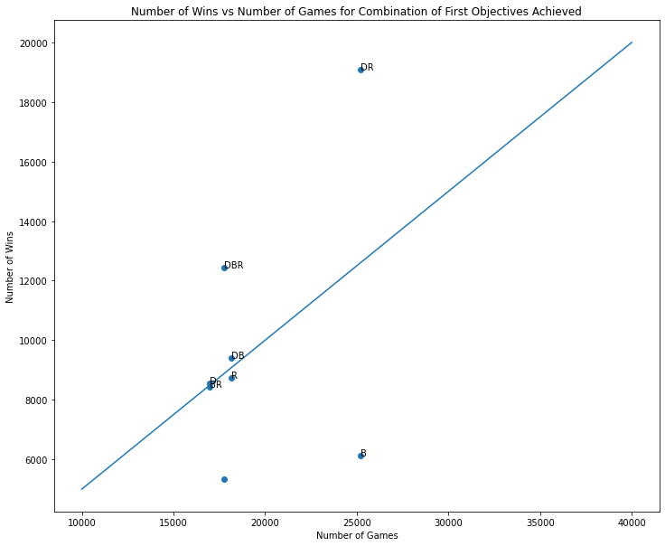

```python
fig, ax = plt.subplots(figsize=(12, 10))

X = firstKills.Total
Y = firstKills.Count

#plot winrates of each combination of first objectives
ax.scatter(X, Y)

# Annotate points
for idx, row in firstKills.iterrows():
    ax.annotate(row['Legend'], (row['Total'], row['Count']))

# Create 50% win rate line
y = [5000,20000]
x = [10000,40000]

#Add labels and title
plt.xlabel("Number of Games")
plt.ylabel("Number of Wins")
plt.title("Number of Wins vs Number of Games for Combination of First Objectives Achieved")


# Plot 50% win rate
plt.plot(x, y)

plt.show()
```

We can see that games overwhelmingly develop to a point where one team achieves first Dragon and first Rift Herald and another team wins Baron with the former winning much more. Similarly, teams that achieve all three win much more than their counterparts that achieve none, but surprisingly the difference is not as much as just achieving first Dragon and first Rift Herald. We can also see that just achieving first Dragon allows teams to be roughly on par with teams that achieve first Rift Herald and Baron, indicating that the first Dragon is more beneficial to winning a game than the other two combined.

### Benefits of Taking More Objectives

Another statistic we can look to see the significance of each bonus objective is how likely teams are to win given how many times they achieved a bonus objective. However, since both teams can achieve the same objectives, we will look at the differences in the amount of objectives both teams achieved.

```python
#Get difference between teams
diffs = pd.DataFrame()
diffs['DragDiff'] = final['dk_win'] - final['dk_loss']
diffs['BaronDiff'] = final['bk_win'] - final['bk_loss']
diffs['RiftDiff'] = final['rhk_win'] - final['rhk_loss']
diffs
```

|  | DragDiff | BaronDiff | RiftDiff |
| --- | --- | --- | --- |
| 0 | 3 | 0 | 2 |
| 1 | 2 | 0 | 2 |
| 2 | 2 | 0 | 2 |
| 3 | 2 | 0 | 1 |
| 4 | -1 | 1 | 2 |
| ... | ... | ... | ... |
| 109155 | 1 | 0 | 1 |
| 109156 | 1 | 1 | 2 |
| 109157 | 1 | 0 | 1 |
| 109161 | 0 | 1 | -2 |
| 109162 | 0 | 2 | 0 |

78123 rows × 3 columns

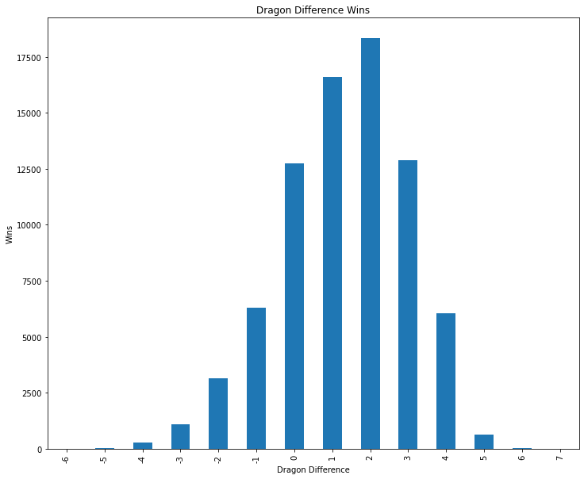

```python
# Show difference of wins for each objective difference
diffs.DragDiff.value_counts().sort_index(ascending=True).plot(kind = 'bar', title = 'Dragon Difference Wins', figsize=(12, 10), xlabel = 'Dragon Difference', ylabel = 'Wins')
```

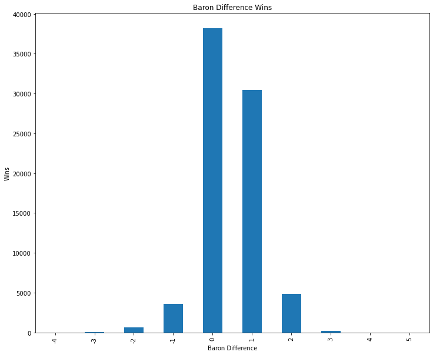

```python
diffs.BaronDiff.value_counts().sort_index(ascending=True).plot(kind = 'bar', title = 'Baron Difference Wins', figsize=(12, 10), xlabel = 'Baron Difference', ylabel = 'Wins')
```

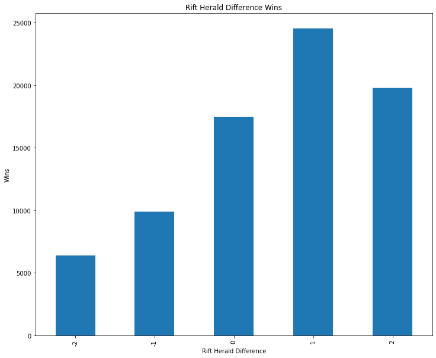

```python
diffs.RiftDiff.value_counts().sort_index(ascending=True).plot(kind = 'bar', title = 'Rift Herald Difference Wins', figsize=(12, 10), xlabel = 'Rift Herald Difference', ylabel = 'Wins')
```

We can also look at these differences individually by plotting the win rates of the teams that achieve each individual objective difference.

```
<BarContainer object of 14 artists>
```

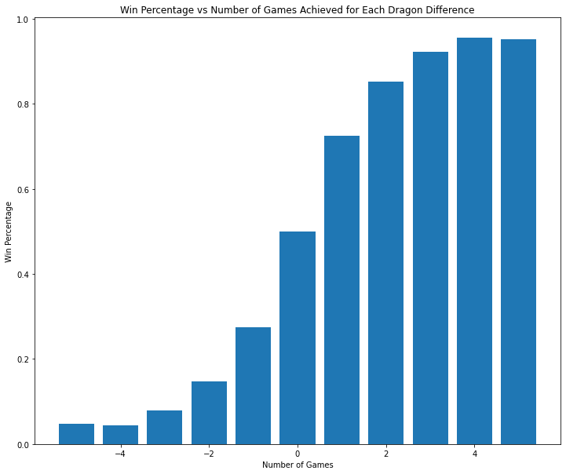

```python
# Show effects of Dragon differences individually
dragdiff = pd.DataFrame()
dragdiff['wins'] = diffs.DragDiff.value_counts()

# Get the number of times a team achieved a certain difference
dragdiff.loc[-5, 'total'] = (dragdiff.loc[5, 'wins'] + dragdiff.loc[-5, 'wins'])
dragdiff.loc[-4, 'total'] = (dragdiff.loc[4, 'wins'] + dragdiff.loc[-4, 'wins'])
dragdiff.loc[-3, 'total'] = (dragdiff.loc[3, 'wins'] + dragdiff.loc[-3, 'wins'])
dragdiff.loc[-2, 'total'] = (dragdiff.loc[2, 'wins'] + dragdiff.loc[-2, 'wins'])
dragdiff.loc[-1, 'total'] = (dragdiff.loc[1, 'wins'] + dragdiff.loc[-1, 'wins'])
dragdiff.loc[0, 'total'] = dragdiff.loc[0, 'wins']
dragdiff.loc[5, 'total'] = (dragdiff.loc[5, 'wins'] + dragdiff.loc[-5, 'wins'])
dragdiff.loc[4, 'total'] = (dragdiff.loc[4, 'wins'] + dragdiff.loc[-4, 'wins'])
dragdiff.loc[3, 'total'] = (dragdiff.loc[3, 'wins'] + dragdiff.loc[-3, 'wins'])
dragdiff.loc[2, 'total'] = (dragdiff.loc[2, 'wins'] + dragdiff.loc[-2, 'wins'])
dragdiff.loc[1, 'total'] = (dragdiff.loc[1, 'wins'] + dragdiff.loc[-1, 'wins'])

# Calculate win percent
dragdiff['win_percent'] = dragdiff['wins']/dragdiff['total']
dragdiff.loc[0, 'win_percent'] = 0.5
dragdiff['diff'] = dragdiff.index

fig, ax = plt.subplots(figsize=(12,10))

X = dragdiff['diff']
Y = dragdiff.win_percent

#Add labels and title
plt.xlabel("Number of Games")
plt.ylabel("Win Percentage")
plt.title("Win Percentage vs Number of Games Achieved for Each Dragon Difference")

#Plot winrates of each combination of first objectives
ax.bar(X, Y)
```

```
<BarContainer object of 10 artists>
```

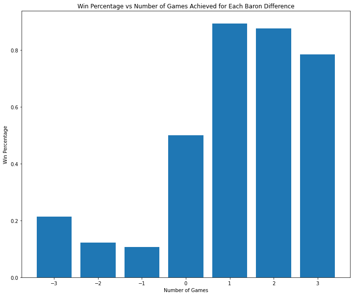

```python
# Show effects of Baron differences individually
barondiff = pd.DataFrame()
barondiff['wins'] = diffs.BaronDiff.value_counts()

barondiff.loc[-3, 'total'] = (barondiff.loc[3, 'wins'] + barondiff.loc[-3, 'wins'])
barondiff.loc[-2, 'total'] = (barondiff.loc[2, 'wins'] + barondiff.loc[-2, 'wins'])
barondiff.loc[-1, 'total'] = (barondiff.loc[1, 'wins'] + barondiff.loc[-1, 'wins'])
barondiff.loc[0, 'total'] = (barondiff.loc[0, 'wins'])
barondiff.loc[3, 'total'] = (barondiff.loc[3, 'wins'] + barondiff.loc[-3, 'wins'])
barondiff.loc[2, 'total'] = (barondiff.loc[2, 'wins'] + barondiff.loc[-2, 'wins'])
barondiff.loc[1, 'total'] = (barondiff.loc[1, 'wins'] + barondiff.loc[-1, 'wins'])

# Calculate win percent
barondiff['win_percent'] = barondiff['wins']/barondiff['total']
barondiff.loc[0, 'win_percent'] = 0.5
barondiff['diff'] = barondiff.index

fig, ax = plt.subplots(figsize=(12, 10))

X = barondiff['diff']
Y = barondiff.win_percent

#Add labels and title
plt.xlabel("Number of Games")
plt.ylabel("Win Percentage")
plt.title("Win Percentage vs Number of Games Achieved for Each Baron Difference")

#plot winrates of each combination of first objectives
ax.bar(X, Y)
```

```
<BarContainer object of 5 artists>
```

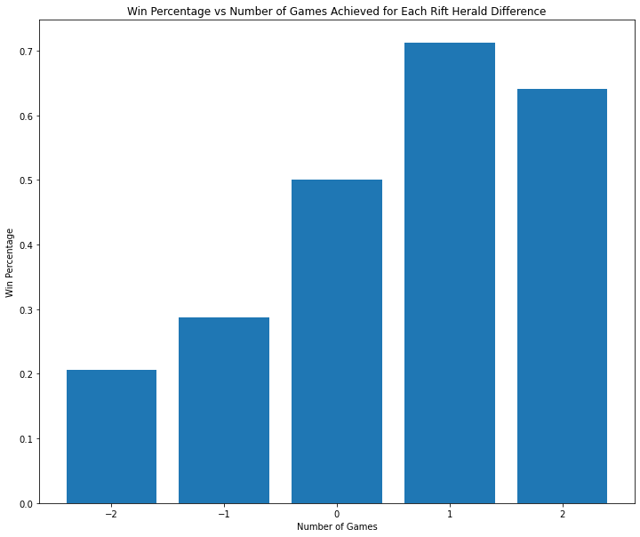

```python
# Looking at the effects of Rift Herald Differences individually
riftdiff = pd.DataFrame()
riftdiff['wins'] = diffs.RiftDiff.value_counts()

# Get the number of times a team achieved a certain difference
riftdiff.loc[1, 'total'] = (riftdiff.loc[1, 'wins'] + riftdiff.loc[-1, 'wins'])
riftdiff.loc[2, 'total'] = (riftdiff.loc[1, 'wins'] + riftdiff.loc[-2, 'wins'])
riftdiff.loc[0, 'total'] = (riftdiff.loc[0, 'wins'])
riftdiff.loc[-1, 'total'] = (riftdiff.loc[1, 'wins'] + riftdiff.loc[-1, 'wins'])
riftdiff.loc[-2, 'total'] = (riftdiff.loc[1, 'wins'] + riftdiff.loc[-2, 'wins'])

# Calculate win percent
riftdiff['win_percent'] = riftdiff['wins']/riftdiff['total']
riftdiff.loc[0, 'win_percent'] = 0.5
riftdiff['diff'] = riftdiff.index

fig, ax = plt.subplots(figsize=(12, 10))

X = riftdiff['diff']
Y = riftdiff.win_percent

#Add labels and title
plt.xlabel("Number of Games")
plt.ylabel("Win Percentage")
plt.title("Win Percentage vs Number of Games Achieved for Each Rift Herald Difference")

#plot winrates of each combination of first objectives
ax.bar(X, Y)
```

From the graphs above, we can see that win rate cleanly correlates with having more dragons than the opposing team. For Barons and Rift Heralds, the linear correlation is not as obvious but it is still clear that having at least one more of either objective gives a higher win percentage.

### Do Objectives affect Win Rate?

After determining that taking objectives has a correlation with win rate, one other factor that can affect win rate is game duration. Every major objective in league has a respawn timer of 5-8 minutes, so taking more objectives as the game goes on may skew results. In order to factor out game duration, the objective capture difference can be divided by the total number of each objective captured in order to give a ratio of objectives taken relatively each game, because taking 3 out of four dragons may have a different amount of significance compared to taking 5 out of 6 dragons.

The first step is to take the difference of each objective and divide it by the total objectives taken to get the ratio of objectives taken vs total objectives. The data is stored in a dataframe separate from the other data to keep analysis tidy.

```python
finald = final.copy()
finald['DDiff'] = finald['dk_win'] - finald['dk_loss']
finald['DTotal'] = finald['dk_win'] + finald['dk_loss']
finald['DRatio'] = finald['DDiff']/finald['DTotal']
finald['BDiff'] = finald['bk_win'] - finald['bk_loss']
finald['BTotal'] = finald['bk_win'] + finald['bk_loss']
finald['BRatio'] = finald['BDiff']/finald['BTotal']
finald['RHDiff'] = finald['rhk_win'] - finald['rhk_loss']
finald['RHTotal'] = finald['rhk_win'] + finald['rhk_loss']
finald['RHRatio'] = finald['RHDiff']/finald['RHTotal']
finald['BRatio'] = finald['BRatio'].fillna(0)
finald['RHRatio'] = finald['RHRatio'].fillna(0)
finald['Diff'] = finald['DDiff'] + finald['BDiff'] + finald['RHDiff']
finald['Total'] = finald['DTotal'] + finald['BTotal'] + finald['RHTotal']
finald['Ratio'] = finald['Diff']/finald['Total']
finalr = finald[['DRatio','BRatio','RHRatio','Ratio']].copy()
finald
```

|  | dk_win | bk_win | rhk_win | dk_loss | bk_loss | rhk_loss | firstDk_win | firstBk_win | firstRHk_win | DDiff | ... | DRatio | BDiff | BTotal | BRatio | RHDiff | RHTotal | RHRatio | Diff | Total | Ratio |
| --- | --- | --- | --- | --- | --- | --- | --- | --- | --- | --- | --- | --- | --- | --- | --- | --- | --- | --- | --- | --- | --- |
| 0 | 3 | 0 | 2 | 0 | 0 | 0 | True | False | True | 3 | ... | 1.000000 | 0 | 0 | 0.000000 | 2 | 2 | 1.0 | 5 | 5 | 1.000000 |
| 1 | 2 | 0 | 2 | 0 | 0 | 0 | True | False | True | 2 | ... | 1.000000 | 0 | 0 | 0.000000 | 2 | 2 | 1.0 | 4 | 4 | 1.000000 |
| 2 | 2 | 0 | 2 | 0 | 0 | 0 | True | False | True | 2 | ... | 1.000000 | 0 | 0 | 0.000000 | 2 | 2 | 1.0 | 4 | 4 | 1.000000 |
| 3 | 3 | 1 | 1 | 1 | 1 | 0 | False | False | True | 2 | ... | 0.500000 | 0 | 2 | 0.000000 | 1 | 1 | 1.0 | 3 | 7 | 0.428571 |
| 4 | 2 | 2 | 2 | 3 | 1 | 0 | True | True | True | -1 | ... | -0.200000 | 1 | 3 | 0.333333 | 2 | 2 | 1.0 | 2 | 10 | 0.200000 |
| ... | ... | ... | ... | ... | ... | ... | ... | ... | ... | ... | ... | ... | ... | ... | ... | ... | ... | ... | ... | ... | ... |
| 109155 | 1 | 0 | 1 | 0 | 0 | 0 | True | False | True | 1 | ... | 1.000000 | 0 | 0 | 0.000000 | 1 | 1 | 1.0 | 2 | 2 | 1.000000 |
| 109156 | 2 | 1 | 2 | 1 | 0 | 0 | False | True | True | 1 | ... | 0.333333 | 1 | 1 | 1.000000 | 2 | 2 | 1.0 | 4 | 6 | 0.666667 |
| 109157 | 1 | 0 | 1 | 0 | 0 | 0 | True | False | True | 1 | ... | 1.000000 | 0 | 0 | 0.000000 | 1 | 1 | 1.0 | 2 | 2 | 1.000000 |
| 109161 | 2 | 1 | 0 | 2 | 0 | 2 | False | True | False | 0 | ... | 0.000000 | 1 | 1 | 1.000000 | -2 | 2 | -1.0 | -1 | 7 | -0.142857 |
| 109162 | 3 | 2 | 1 | 3 | 0 | 1 | False | True | False | 0 | ... | 0.000000 | 2 | 2 | 1.000000 | 0 | 2 | 0.0 | 2 | 10 | 0.200000 |

78123 rows × 21 columns

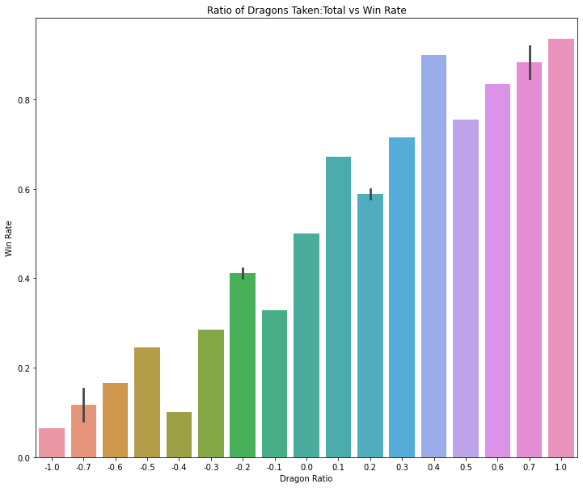

```python
dwrg = finalr.groupby(['DRatio'])['DRatio'].count()
dwrg = dwrg.to_frame()
dwrg = dwrg.rename(columns={"DRatio" : "count"})
dwrg = dwrg.reset_index()
dwrg = dwrg.drop(axis=0, index=11)
dwrg = dwrg.reset_index(drop=True)
dwrg2 = dwrg.loc[::-1].reset_index(drop=True)
dwrg2 = dwrg2.rename(columns={"count" : "countloss", "DRatio" : "Ratioloss"})
dwrg = dwrg.join(dwrg2)
dwrg['Win Rate'] = dwrg['count']/(dwrg['count'] + dwrg['countloss'])
dwrg['DRatio'] = dwrg['DRatio'].map('{:,.1f}'.format)
plt.figure(figsize=(12,10))
ax = seaborn.barplot(x=dwrg['DRatio'], y=dwrg['Win Rate']).set(title='Ratio of Dragons Taken:Total vs Win Rate', xlabel='Dragon Ratio')
```

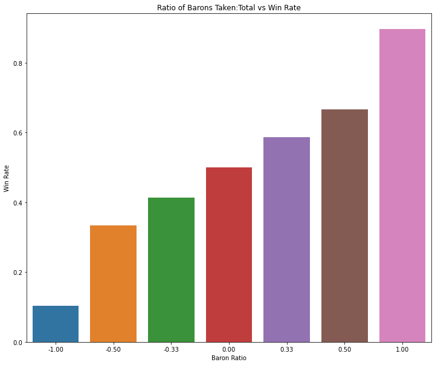

```python
bwrg = finalr.groupby(['BRatio'])['BRatio'].count()
bwrg = bwrg.to_frame()
bwrg = bwrg.rename(columns={"BRatio" : "count"})
bwrg = bwrg.reset_index()
bwrg['BRatio'] = bwrg['BRatio'].map('{:,.2f}'.format)
bwrg = bwrg.drop(axis=0, index=6)
bwrg = bwrg.reset_index(drop=True)
bwrg2 = bwrg.loc[::-1].reset_index(drop=True)
bwrg2 = bwrg2.rename(columns={"count" : "countloss", "BRatio" : "Ratioloss"})
bwrg = bwrg.join(bwrg2)
bwrg['Win Rate'] = bwrg['count']/(bwrg['count']+bwrg['countloss'])
plt.figure(figsize=(12,10))
ax = seaborn.barplot(x=bwrg['BRatio'], y=bwrg['Win Rate']).set(title='Ratio of Barons Taken:Total vs Win Rate',xlabel='Baron Ratio')
```

[output not shown]

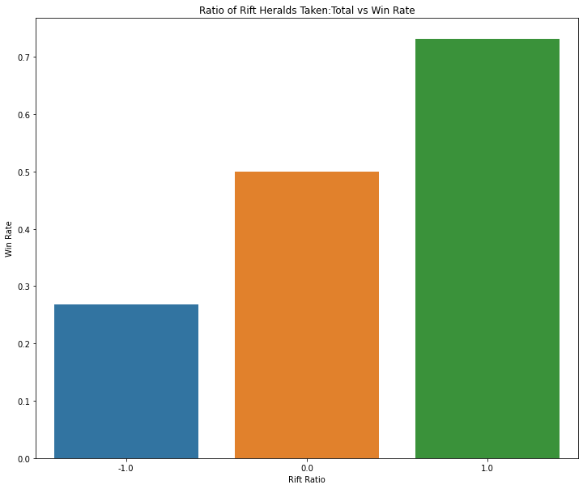

```python
rhwrg = finalr.groupby(['RHRatio'])['RHRatio'].count()
rhwrg = rhwrg.to_frame()
rhwrg = rhwrg.rename(columns={"RHRatio" : "count"})
rhwrg = rhwrg.reset_index()
rhwrg = rhwrg.reset_index(drop=True)
rhwrg2 = rhwrg.loc[::-1].reset_index(drop=True)
rhwrg2 = rhwrg2.rename(columns={"count" : "countloss", "RHRatio" : "Ratioloss"})
rhwrg = rhwrg.join(rhwrg2)
rhwrg['Win Rate'] = rhwrg['count']/(rhwrg['count']+rhwrg['countloss'])
plt.figure(figsize=(12,10))
seaborn.barplot(x=rhwrg['RHRatio'], y=rhwrg['Win Rate']).set(title='Ratio of Rift Heralds Taken:Total vs Win Rate',xlabel='Rift Ratio')
```

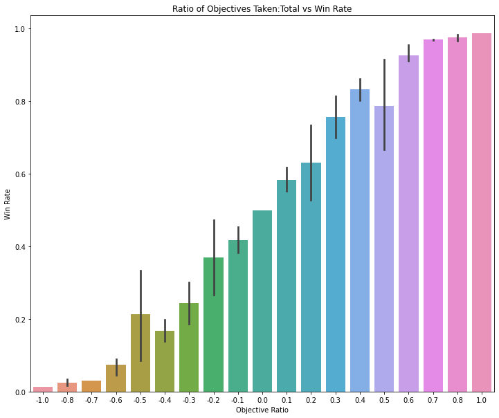

```python
wrg = finalr.groupby(['Ratio'])['Ratio'].count()
wrg = wrg.to_frame()
wrg = wrg.rename(columns={"Ratio" : "count"})
wrg = wrg.reset_index()
wrg = wrg.drop(axis=0, index=[52,51,50,49,45,38,34])
wrg['Ratio'] = wrg['Ratio'].map('{:,.1f}'.format)
wrg =  wrg.reset_index(drop=True)
wrg2 = wrg.loc[::-1].reset_index(drop=True)
wrg2 = wrg2.rename(columns={"count" : "countloss", "Ratio" : "Ratioloss"})
wrg = wrg.join(wrg2)
wrg['Win Rate'] = wrg['count']/(wrg['count']+wrg['countloss'])
plt.figure(figsize=(12,10))
ax = seaborn.barplot(x=wrg['Ratio'], y=wrg['Win Rate']).set(title='Ratio of Objectives Taken:Total vs Win Rate',xlabel='Objective Ratio')
```

Game duration and relative objectives work hand in hand with respect to determining win rate. Having more objectives with respect to the opponent tends to show a stronger correlation compared to having just a greater number of objectives.

### Predicting a win based on objectives

Here we will see if these bonus objectives are clearly correlated with winning by seeing if we can predict wins based on the factors of a team's Dragons, Barons, and Rift Heralds, their opponents Dragons, Barons, and Rift Heralds, and who got which objectives first.

We will first create a dataset from the perspective of the individual teams and then use their perspective to predict if they won. Since each game has a winner and loser, we will split the dataset into half of the winning perspective and half of the losing perspective.

```python
# Create dataframe for machine learning testing
df = pd.DataFrame()

# Add half of games of games from perspective of winner
# and half as perspective of loser
for i in range(0, len(final)):
    if (i % 2 == 0):
        df.loc[i, 'dk'] = final.iloc[i]['dk_win']
        df.loc[i, 'bk'] = final.iloc[i]['bk_win']
        df.loc[i, 'rhk'] = final.iloc[i]['rhk_win']
        df.loc[i, 'fd'] = final.iloc[i]['firstDk_win']
        df.loc[i, 'fb'] = final.iloc[i]['firstBk_win']
        df.loc[i, 'frh'] = final.iloc[i]['firstRHk_win']
        df.loc[i, 'edk'] = final.iloc[i]['dk_loss']
        df.loc[i, 'ebk'] = final.iloc[i]['bk_loss']
        df.loc[i, 'erhk'] = final.iloc[i]['rhk_loss']
        df.loc[i, 'result'] = "1"
    else:
        df.loc[i, 'dk'] = final.iloc[i]['dk_loss']
        df.loc[i, 'bk'] = final.iloc[i]['bk_loss']
        df.loc[i, 'rhk'] = final.iloc[i]['rhk_loss']
        df.loc[i, 'fd'] = ~final.iloc[i]['firstDk_win']
        df.loc[i, 'fb'] = ~final.iloc[i]['firstBk_win']
        df.loc[i, 'frh'] = ~final.iloc[i]['firstRHk_win']
        df.loc[i, 'edk'] = final.iloc[i]['dk_win']
        df.loc[i, 'ebk'] = final.iloc[i]['bk_win']
        df.loc[i, 'erhk'] = final.iloc[i]['rhk_win']
        df.loc[i, 'result'] = "0"

# Randomly scramble rows
test_df = df.sample(frac=1).reset_index(drop=True)

test_df
```

|  | dk | bk | rhk | fd | fb | frh | edk | ebk | erhk | result |
| --- | --- | --- | --- | --- | --- | --- | --- | --- | --- | --- |
| 0 | 2.0 | 2.0 | 1.0 | True | True | True | 2.0 | 0.0 | 0.0 | 0 |
| 1 | 3.0 | 0.0 | 0.0 | True | True | False | 0.0 | 0.0 | 2.0 | 0 |
| 2 | 4.0 | 0.0 | 1.0 | True | False | True | 0.0 | 0.0 | 0.0 | 1 |
| 3 | 1.0 | 0.0 | 1.0 | False | True | True | 2.0 | 0.0 | 1.0 | 0 |
| 4 | 1.0 | 0.0 | 0.0 | True | True | False | 1.0 | 0.0 | 1.0 | 0 |
| ... | ... | ... | ... | ... | ... | ... | ... | ... | ... | ... |
| 78118 | 3.0 | 0.0 | 1.0 | True | False | True | 2.0 | 2.0 | 0.0 | 1 |
| 78119 | 3.0 | 1.0 | 1.0 | False | True | True | 2.0 | 1.0 | 1.0 | 1 |
| 78120 | 2.0 | 0.0 | 0.0 | False | False | False | 3.0 | 1.0 | 1.0 | 1 |
| 78121 | 0.0 | 0.0 | 1.0 | False | True | True | 2.0 | 0.0 | 0.0 | 0 |
| 78122 | 0.0 | 0.0 | 1.0 | False | False | True | 3.0 | 1.0 | 0.0 | 0 |

78123 rows × 10 columns

We will then create a training set and a test set with the test set being 25% of the total data.

```python
# Split dataset into training and test sets
X = test_df[['dk', 'bk', 'rhk', 'fd', 'fb', 'frh', 'edk', 'ebk', 'erhk']].copy()
y = test_df[['result']].copy()

# Test set is 25% of total dataset
X_train, X_test, y_train, y_test = train_test_split(X, y, test_size = 0.25)
```

Finally, using decision trees and random forest classifiers, we will try to predict whether or not a team won or lost.

```python
dtClassifier = DecisionTreeClassifier()
dtClassifier.fit(X_train, y_train)

#Use decision tree classifier to predict wins from data in test set
dt_pred= dtClassifier.predict(X_test)

#Compare predicted wins with real wins in test set
print(metrics.classification_report(y_test, dt_pred))
```

```
              precision    recall  f1-score   support

           0       0.93      0.95      0.94      9707
           1       0.95      0.93      0.94      9824

    accuracy                           0.94     19531
   macro avg       0.94      0.94      0.94     19531
weighted avg       0.94      0.94      0.94     19531
```

```python
rfClassifier = RandomForestClassifier()
rfClassifier.fit(X_train, np.ravel(y_train,order='C'))

#Use random forest classifier to predict wins from data in test set
rf_pred= rfClassifier.predict(X_test)

#Compare predicted wins with real wins in test set
print(metrics.classification_report(y_test, rf_pred))
```

```
              precision    recall  f1-score   support

           0       0.94      0.94      0.94      9707
           1       0.94      0.94      0.94      9824

    accuracy                           0.94     19531
   macro avg       0.94      0.94      0.94     19531
weighted avg       0.94      0.94      0.94     19531
```

As can be seen above, both decision trees and random forest classifiers can accurately predict whether or not a team won or not based on the bonus objectives. The f1-score of 0.94 shows that there are few cases where the tested set was predicted wrongly. The high accuracy of the model shows that the three bonus objectives are extremely correlated with whether or not a team wins.

## Conclusion

From our analysis, we can see that the bonus objectives in League of Legends are tied very close to whether or not a team wins. We learned that getting Dragon and Rift Herald first is very beneficial, whereas getting Baron first is not as significant. Furthermore, we learned that for all three bonus objectives there is a clear benefit to always having more of these objectives than the opponent, especially Dragons.

Hopefully our tutorial will help shed some light on the importance of these bonus objectives to players, whether it be by emphasizing the significance of Dragon or deemphasizing the significance of Baron. For those interested in doing further analysis on this subject, we would recommend analyzing the timestamps for each objective. Unfortunately the data provided by the Kaggle dataset did not include this, but directly getting the data from Riot's API should contain this information. In addition for those that want to analyze the significance of other factors like team composition or gold difference, the Kaggle dataset does include this information. Our tutorial only touched the surface of what there is to look at, and we hope that reading it will make both old and new players more interested in playing the game.